# Assignment

Anderson Uyekita

1 de dezembro de 2018

## Assignment Week 2

Esta é uma tentativa de refazer o Assignment Week 2 usando o R.

```r
# Loading Libraries
library(readr)
library(ggplot2)
library(dplyr)
```

O *dataset* possui as seguintes primeiros dados.

```r
# Loading the data set
# First column = population
# Second Column = profit of food truck
df_ex1 <- read_csv(file = "C:/Users/ander/Documents/machine_learning/machine-learning-ex1/ex1/ex1data1.txt",col_names = c("pop","profit"))

head(df_ex1)
```

```
## # A tibble: 6 x 2
##     pop profit
##   <dbl>  <dbl>
## 1  6.11  17.6
## 2  5.53   9.13
## 3  8.52  13.7
## 4  7.00  11.9
## 5  5.86   6.82
## 6  8.38  11.9
```

O gráfico abaixo apresenta Profit vs população.

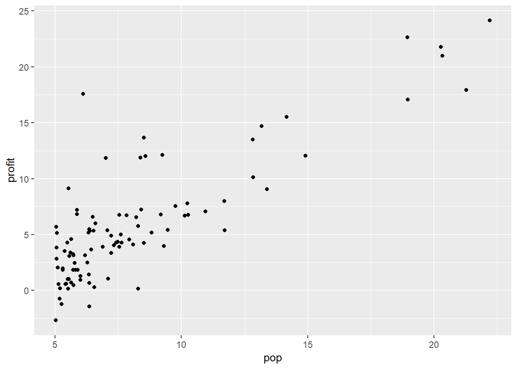

```r
# Plotting the Graphic
ggplot(df_ex1,aes(x = pop, y = profit)) +
       geom_point()
```

Conforme as instruções, calcula-se inicialmente o *Cost Function* que é definido por:

$$J(\theta) = \frac{1}{2m} \sum_{i=1}^m{ (h_\theta(x^{(i)})-y^{(i)})^2} \tag{1}$$

A equação (1) pode ser reescrita usando-se os conceitos de matrizes e pelo fato de $h_\theta(x^{(i)})$ ser o mesmo que $\theta^Tx^{(i)}$.

$$J(\theta) = \frac{1}{2m} \sum_{i=1}^m{\begin{pmatrix}\theta^Tx^{(i)} - y^{(i)}\end{pmatrix}^2}\tag{2}$$

Observe que na equação (2) $\theta^T$ é um vetor coluna que possui todos os coeficientes da hipótese adotada, neste problema adotou-se dois $\theta$.

$$\theta = \begin{bmatrix} \theta_0 \\ \theta_1 \end{bmatrix} \text{ Logo,}\\
\theta^T = \begin{bmatrix} \theta_0 \ \ \theta_1 \end{bmatrix} \tag{3}$$

Para o caso de $x^{(i)}$ será também um vetor coluna cujos valores são os x’s do *training data*.

$$x^{(i)} = \begin{bmatrix} x_0^{(i)} \\ x_1^{(i)} \end{bmatrix} \tag{4}$$
Substituindo-se as equações (3) e (4) em (2), tem-se:

$$J(\theta_0, \theta_1) = \frac{1}{2m} \sum_{i=1}^m{\begin{pmatrix}
\begin{bmatrix} \theta_0 \ \ \theta_1 \end{bmatrix}\begin{bmatrix} x_0^{(i)} \\ x_1^{(i)} \end{bmatrix} -
y^{(i)}\end{pmatrix}^2}\tag{5}$$

A mágica do uso de matrizes para calcular o somatório do quadrado de cada elemento da matriz pode ser feito conforme a equação (6).

$$A = \begin{bmatrix} a_{i1} \\ a_{i2} \\ \vdots \\ a_{n1}\end{bmatrix}$$

$$A^T * A = \begin{bmatrix} a_{i1} \ \ a_{i2} \ \ \vdots \ \ a_{n1}\end{bmatrix}
\begin{bmatrix} a_{i1} \\ a_{i2} \\ \vdots \\ a_{n1}\end{bmatrix} = a_{i1}^2 + a_{i2}^2 + \dots + a_{i3}^2$$

$$A^T * A = \sum_{i = 1}^{n}a_i^2 \tag{6}$$
Utilizando o conceito da equação (6) em (5), tem-se:

$$A = \begin{bmatrix}{
\begin{bmatrix} \theta_0 \ \ \theta_1 \end{bmatrix}\begin{bmatrix} x_0^{(1)} \\ x_1^{(1)} \end{bmatrix} -
y^{(1)}\\
\begin{bmatrix} \theta_0 \ \ \theta_1 \end{bmatrix}\begin{bmatrix} x_0^{(2)} \\ x_1^{(2)} \end{bmatrix} -
y^{(2)} \\ \vdots \\
\begin{bmatrix} \theta_0 \ \ \theta_1 \end{bmatrix}\begin{bmatrix} x_0^{(m)} \\ x_1^{(m)} \end{bmatrix} -
y^{(m)}}\end{bmatrix}\tag{6}$$

Note que a matriz A é uma matriz coluna de *m* elementos. Utilizando outro truque, transforma-se esses vários produtos de vetores ($\theta$ e $x$) conforme o exemplo da equação (7).

$$\begin{bmatrix} a_{11} \ b_{12} \\ a_{21} \ b_{22} \\ \vdots \\ a_{n1} \ b_{n2}\end{bmatrix}
\begin{bmatrix} \beta_0 \\ \beta_1 \end{bmatrix} =
\begin{bmatrix}
\begin{bmatrix} a_{11} \ b_{12} \end{bmatrix} \begin{bmatrix} \beta_0 \\ \beta_1 \end{bmatrix} \\
\begin{bmatrix} a_{21} \ b_{22} \end{bmatrix} \begin{bmatrix} \beta_0 \\ \beta_1 \end{bmatrix} \\
\vdots \\
\begin{bmatrix} a_{n1} \ b_{n2} \end{bmatrix} \begin{bmatrix} \beta_0 \\ \beta_1 \end{bmatrix}
\end{bmatrix} \tag{7}$$

Nota-se uma similariedade entre a equação (6) e (7), exceto o fato do $y_i$, que pode ser isolado como um vetor $Y$.

$$A = \underbrace{\begin{bmatrix}
x_0^{(1)} \ x_1^{(1)} \\
x_0^{(2)} \ x_1^{(2)} \\
\vdots \\
x_0^{(m)} \ x_1^{(m)}
\end{bmatrix}}_{\hat X}
\underbrace{
\begin{bmatrix}
\theta_0 \\ \theta_1
\end{bmatrix}}_{\hat \theta} -
\underbrace{\begin{bmatrix}
y^{(1)} \\ y^{(2)} \\ \vdots \\ y^{(m)}
\end{bmatrix}}_{\hat Y} =
\begin{bmatrix}{
\begin{bmatrix} \theta_0 \ \ \theta_1 \end{bmatrix}\begin{bmatrix} x_0^{(1)} \\ x_1^{(1)} \end{bmatrix} -
y^{(1)}\\
\begin{bmatrix} \theta_0 \ \ \theta_1 \end{bmatrix}\begin{bmatrix} x_0^{(2)} \\ x_1^{(2)} \end{bmatrix} -
y^{(2)} \\ \vdots \\
\begin{bmatrix} \theta_0 \ \ \theta_1 \end{bmatrix}\begin{bmatrix} x_0^{(m)} \\ x_1^{(m)} \end{bmatrix} -
y^{(m)}}\end{bmatrix} = \hat X \hat \theta - \hat Y\tag{8}$$

Observe que $\hat X$ é uma matriz cuja primeira coluna é de 1 (devido à constante $\theta_0$ que não possui nenhum $x_0$ associado) e a segunda coluna são os valores de $x_1^{(i)}$. Uma outra maneira de anotar $\hat X$ é conforme a equação (9).

$$\hat X = \begin{bmatrix} - x^{(1)} - \\ - x^{(2)} - \\ \vdots \\ - x^{(m)} - \end{bmatrix} =
\begin{bmatrix}
x_0^{(1)} \ x_1^{(1)} \\
x_0^{(2)} \ x_1^{(2)} \\
\vdots \\
x_0^{(m)} \ x_1^{(m)}
\end{bmatrix} \tag{10}$$

Logo, a equação 2 pode ser reescrita conforme a equação (11).

$$J(\theta) = \frac{1}{2m} (\hat X \hat \theta - \hat Y)^T(\hat X \hat \theta - \hat Y) \tag{11}$$
Observe que essa equação é a mesma que aparece na página 12, item 3.2 do arquivo ex1.pdf.

```r
# Creating the X matrix
df_ex1 %>% select(pop) %>% mutate(cons = 1) %>% select(cons,pop) -> X

# Defining theta as a column
theta <- matrix(c(0,0),ncol =1)

# Creating the real output vector
y <- df_ex1 %>% select(profit)

# Calculating A
A <- as.matrix(X) %*% theta - as.matrix(y)

# Calculating the Cost Function
J <- 1/(2*nrow(df_ex1)) * t(A) %*% A
```

## Atualização de $\hat \theta$

Os valores de $\theta$ podem ser atualizados a partir da derivada de $J(\theta)$, conforme a equação (12).

$$\theta_j = \theta_j - \alpha \frac{1}{m} \frac{\partial}{\partial \theta_j}J(\hat \theta) \tag{12}$$

Onde $\frac{\partial}{\partial \theta_j}J(\hat \theta)$ é a derivada parcial e detalhada na equação (13).

$$\frac{\partial}{\partial \theta_j}J(\hat \theta) = \sum_{i = 1}^{m}{(h_\theta(x^{(i)}) - y^{(i)})x_j^{(i)}} \tag{13}$$

Substituindo-se a hipótese ($h_\theta(x^{(i)})$) por $\theta_0x_0 + \theta_1x_1$, tem-se:

$$\frac{\partial}{\partial \theta_j}J(\hat \theta) = \sum_{i = 1}^{m}{\underbrace{( \theta_0 x_0^{(i)} + \theta_1 x_1^{(i)} - y^{(i)})}_{A}x_j^{(i)}} \tag{13}$$

Observe que a equação (13) possui um fragmento da equação (6), o que nos leva a reescrevê-la de uma outra forma de acordo com a equação (14).

$$\frac{\partial}{\partial \theta_j}J(\hat \theta) = (\theta_0 x_0^1 + \theta_1 x_1^1 - y^1)x_j^1 + (\theta_0 x_0^2 + \theta_1 x_1^2 - y^2)x_j^2 + \dots + (\theta_0 x_0^m + \theta_1 x_1^m - y^m)x_j^m \tag{14}$$

Sabe-se que $j$ é a quantidade de $\theta$ da nossa hipótese, no caso deste *Assignment* são dois. Desta maneira, tem-se que:

$$\frac{\partial}{\partial \theta_0}J(\hat \theta) = (\theta_0 x_0^1 + \theta_1 x_1^1 - y^1)x_0^1 + \dots + (\theta_0 x_0^m + \theta_1 x_1^m - y^m)x_0^m \\
\frac{\partial}{\partial \theta_1}J(\hat \theta) = (\theta_0 x_0^1 + \theta_1 x_1^1 - y^1)x_1^1 + \dots + (\theta_0 x_0^m + \theta_1 x_1^m - y^m)x_1^m \tag{15}$$

Agregando as duas equações apresentadas em (15):

$$\begin{bmatrix} \frac{\partial}{\partial \theta_0}J(\hat \theta) \\ \frac{\partial}{\partial \theta_2}J(\hat \theta)\end{bmatrix} =
\begin{bmatrix} x_0^1 \ \ x_0^2 \ \ \dots \ \ x_0^m \\ x_1^1 \ \ x_1^2 \ \ \dots \ \ x_1^m \end{bmatrix}
\underbrace{
\begin{bmatrix} \theta_0 x_0^1 + \theta_1 x_1^1 - y^1 \\ \vdots \\
\theta_0 x_0^m + \theta_1 x_1^m - y^m \end{bmatrix}}_{\hat B} \tag{16}$$

Desmembrando $\hat B$, tem-se:

$$\hat B = \begin{bmatrix} x_0^1 \ \ x_1^1 \\ \vdots \\ x_0^m \ \ x_1^m \end{bmatrix}
\begin{bmatrix} \theta_0 \\ \theta_1 \end{bmatrix} -
\begin{bmatrix} y^1 \\ \vdots \\ y^m\end{bmatrix}\tag{17}$$

Por fim, substitui-se a equação (17) em (16).

$$\frac{\partial}{\partial \theta_0}J(\hat \theta) = (\theta_0 x_0^1 + \theta_1 x_1^1 - y^1)x_0^1 + \dots + (\theta_0 x_0^m + \theta_1 x_1^m - y^m)x_0^m \\
\frac{\partial}{\partial \theta_1}J(\hat \theta) = (\theta_0 x_0^1 + \theta_1 x_1^1 - y^1)x_1^1 + \dots + (\theta_0 x_0^m + \theta_1 x_1^m - y^m)x_1^m \tag{18}$$

```r
m <- nrow(df_ex1)

iterations = 1
alpha = 0.01

theta - alpha/m * t(X) %*% (as.matrix(X) %*% theta - as.matrix(y))
```

```
##          profit
## cons 0.05839135
## pop  0.65328850
```